# Technical Appendix: Empty Digital Wallets: New Technologies and Old Inequalities

Laura Caron

Spring 2021

This technical appendix computes all of the geospatial analysis associated with the paper *Empty Digital Wallets: New Technologies and Old Inequalities in Digital Financial Services Among Women*

# Data sources

This analysis considers data from several sources. 1. Demographic and Health Surveys 2016. This survey dataset provides the main traditional source of survey data for the paper. It is geo-coded at the cluster level. 2. OpenStreetMap. OpenStreetMap queries provide the basis for the analysis of the locations of existing financial institutions. The Overpass query used to export the data is available [here](http://overpass-turbo.eu/s/Ose). 3. OpenCelliD. This database collects the locations of cell phone towers. This is used to proxy access to mobile digital financial services. It is available [here](https://www.opencellid.org/). The data was pre-processed by converting the range reported in meters to arc degrees using the approximation that 1 meter equals 1/111000 degrees. QGIS was then used to buffer each point to create a circle around each with the range as radius. 4. Gridded Population of the World (GPW), v4. This dataset provides information on population density at a spatial level. The version used estimates population density for 2015 in 5km grids. The data are available [here](https://sedac.ciesin.columbia.edu/data/set/gpw-v4-population-density-adjusted-to-2015-unwpp-country-totals-rev11/data-download). 5. Nighttime lights. This dataset has been popularly used to approximate income. It can be used in this analysis to compute spatial Concentration curves for comparison with other variables. The data are available [here](https://earthobservatory.nasa.gov/features/NightLights/page3.php). 6. Ookla Speed test. This dataset gives mobile network performance. The data from Q1 2019 and can be downloaded [here](https://ookla-open-data.s3.amazonaws.com/shapefiles/performance/type=mobile/year=2019/quarter=1/2019-01-01_performance_mobile_tiles.zip). More information on the data source can be found [here](https://github.com/teamookla/ookla-open-data). The data were taken from Q1 2019 through Q3 2021 and merged in QGIS for speed.

# Setting up the Environment

```r
setwd(path)
renv::restore()
```

```
## * The library is already synchronized with the lockfile.
```

```r
library(knitr)
library(tidyverse)
library(sf)
library(geojsonsf)
library(haven)
library(rgdal)
library(raster)
library(lmtest)
library(sandwich)
library(corrplot)
library(spdep)
library(pastecs)
library(lctools)
library(stargazer)
library(margins)
library(broom)
library(fastDummies)

path <- "C:/Users/laura/OneDrive/Desktop/Laura's computer/Documents/My Own Documents/Research/Empty Digital Wallets/"
options(scipen=5,digits = 4)
```

# 1. Loading the data.

This code loads the appropriate packages needed to conduct the analysis and reads the data.

```r
#dhs.sf <- st_read(dhs.path.i)
#dhs.indiv <- read_dta(dhs.indiv.path.i)

#cell.sf <- read.csv(cell.path.i) %>%
#  st_as_sf(coords=c("lon", "lat"), crs="+proj=longlat +datum=WGS84 +no_defs")

#borders.sf <- st_read(borders.path.i)

#banks.sf <- st_read(banks.path.i) %>%
#  st_cast("POINT")

#popden.raster <- raster(paste0(path,"Data/gpw_v4_population_density_adjusted_to_2015_unwpp_country_totals_rev11_2015_2pt5_min.tif"))

#ntl.raster <- raster(paste0(path,"Data/BlackMarble_2016_01deg_geo.tif"))

#bbox <- st_bbox(borders.sf)

#speedtest.sf <- st_read(paste0(path, "Data/Ookla/", countries.i, "_clipped/", countries.i, "_merged.shp"))

#save(dhs.sf, dhs.indiv, cell.sf, borders.sf, speedtest.sf, banks.sf, popden.raster, ntl.raster, file=paste0(path, "Data/combined_Dec21/combined", countries.i,".Rdata"))

load(paste0(path, "Data/combined_Dec21/combined", countries.i,".Rdata"))
```

# 2. Data Cleaning

This code cleans the data and prepares it into a format from which the outputs can be readily generated. It ensures that missing values are appropriately handled and that data are of the correct class (numeric, string, etc.).

```r
# Convert download speed to Mbps
speedtest.sf$avg_d_mbps <- speedtest.sf$avg_d_kbps/1000

# Clean the individual-level data
dhs.indiv <- dplyr::select(dhs.indiv, v001, v002, v034, v003, v119, v102, v201, v133, v151, v155, v101, v190a, v169a, v169b, v170, v012, v745a, v745b, v501, v701, v730, v732, v478, v477, v719, v739, v850a, v746, v157, v158, v159, v171b, v191a, v191)

dhs.indiv$own_phone <- dhs.indiv$v169a
dhs.indiv$mobile_dfs <- ifelse(dhs.indiv$own_phone ==1, dhs.indiv$v169b, 0)
dhs.indiv$trad_fin <- dhs.indiv$v170
dhs.indiv$eduyears <- ifelse(dhs.indiv$v133 == 98, NA, dhs.indiv$v133)
dhs.indiv$married <- ifelse(!is.na(dhs.indiv$v501), ifelse(dhs.indiv$v501 == 1, 1, 0), NA)
dhs.indiv$region <- factor(dhs.indiv$v101)
dhs.indiv$hhhmale <- ifelse(!is.na(dhs.indiv$v151), ifelse(dhs.indiv$v151 == 1, 1, 0), NA)
dhs.indiv$urban <- ifelse(!is.na(dhs.indiv$v102), ifelse(dhs.indiv$v102 == 1, 1, 0), NA)
dhs.indiv$children <- dhs.indiv$v201
dhs.indiv$own_land <- ifelse(!is.na(dhs.indiv$v745b), ifelse(dhs.indiv$v745b == 0, 0, 1), NA)
dhs.indiv$wealth_index <- factor(dhs.indiv$v190a)
dhs.indiv$wealth <- dhs.indiv$v191
dhs.indiv$age <- dhs.indiv$v012
dhs.indiv$age2 <- dhs.indiv$age^2
dhs.indiv$electricity <- ifelse(dhs.indiv$v119==7, NA, dhs.indiv$v119)
dhs.indiv$only_trad_fin <- ifelse(dhs.indiv$mobile_dfs == 1, 0, dhs.indiv$trad_fin)

# Sample: get rid of observations with missing values
dhs.indiv <- dhs.indiv %>%
  dplyr::select(v001, own_phone, mobile_dfs, trad_fin, eduyears, married, region, hhhmale, region, urban, children, own_land, wealth_index, age, age2, electricity, wealth, only_trad_fin) %>%
  na.omit

# Get the coordinates into their own columns
dhs_coords <- as.data.frame(st_coordinates(dhs.sf$geometry))
names(dhs_coords)[1] = "lon"
names(dhs_coords)[2] = "lat"

dhs.sf$lat <- dhs_coords$lat
dhs.sf$lon <- dhs_coords$lon
rm(dhs_coords)

# Take out 0 longitude values
dhs.sf <- filter(dhs.sf, lon != 0)

# Merge the GPS and individual data
dhs_merged.sf <- left_join(dhs.indiv, dhs.sf, by=c(v001 = "DHSCLUST"))

# Get the banks.sf coordinates
banks_coords <- as.data.frame(st_coordinates(banks.sf$geometry))
names(banks_coords)[1] = "lon"
names(banks_coords)[2] = "lat"

banks.sf$lat <- banks_coords$lat
banks.sf$lon <- banks_coords$lon
rm(banks_coords)

# Use approximation that each degree of latitude is 111 km
# Remove cell tower range for those with 5% most extreme ranges
cell.sf2 <- cell.sf %>%
    filter(quantile(range, 0.99) > range)

cells_range.sf <- st_read(cell_buffer.path.i) %>% filter(quantile(range, 0.99) > range)
dhs_range.sf <-  st_buffer(dhs.sf, 10000)
dhs_range.sf$center_lat<- dhs.sf$lat
dhs_range.sf$center_lon <- dhs.sf$lon

# Calculate cell towers nearby
i <- st_intersects(dhs_range.sf, cells_range.sf)
dhs_range.sf$count_cell <-  apply(as.matrix(i), 1, FUN=sum)
rm(i)
dhs_range.sf$d_cell <- ifelse(dhs_range.sf$count_cell > 0, 1, 0)

# Calculate GSM towers nearby
gsm.sf <- cells_range.sf %>%
    filter(radio == "GSM")

i <- st_intersects(dhs_range.sf, gsm.sf)
dhs_range.sf$count_gsm <-  apply(as.matrix(i), 1, FUN=sum)
rm(i)

# Calculate UMTS towers nearby
umts.sf <- cells_range.sf %>%
    filter(radio == "UMTS")

i <- st_intersects(dhs_range.sf, umts.sf)
dhs_range.sf$count_umts <- apply(as.matrix(i), 1, FUN=sum)
rm(i)

# Calculate LTE towers nearby
lte.sf <- cells_range.sf %>%
    filter(radio == "LTE")

i <- st_intersects(dhs_range.sf, lte.sf)
dhs_range.sf$count_lte <-  apply(as.matrix(i), 1, FUN=sum)
rm(i)

# Calculate banks nearby
i <- st_intersects(dhs_range.sf, banks.sf)
dhs_range.sf$count_banks <-  apply(as.matrix(i), 1, FUN=sum)
rm(i)
dhs_range.sf$d_banks <- ifelse(dhs_range.sf$count_banks > 0, 1, 0)

# Add population density, ntl
dhs_range.sf$popden <- raster::extract(popden.raster, dhs.sf, method="simple")
dhs_range.sf$ntl <- raster::extract(ntl.raster, dhs.sf, method="simple")

# Add speedtest
i <- st_intersects(dhs_range.sf, speedtest.sf)
dhs_range.sf$download <- apply(i, 1, function(z) {
                    speedtest.sf[unlist(z), "avg_d_mbps"] %>%
                    st_drop_geometry() %>%
                    unlist() %>%
                    mean()
                    })
dhs_range.sf$missing_download <- is.na(dhs_range.sf$download)
rm(i)
dhs_range.df <- as.data.frame(dhs_range.sf)

# Summarize to the cluster level
dhs_indiv_sum <- dhs.indiv %>%
    dplyr::mutate(DHSCLUST = v001) %>%
  group_by(DHSCLUST) %>%
    dplyr::summarize(count_indiv = n(),
                     cell_phone_n = sum(own_phone),
                     cell_phone_prop = sum(own_phone)/count_indiv,
                     electricity_n = sum(electricity),
                     electricity_prop = sum(electricity)/count_indiv,
                     mobile_dfs_n = sum(mobile_dfs),
                     mobile_dfs_prop = sum(mobile_dfs)/count_indiv,
                     trad_fin_n = sum(trad_fin),
                     trad_fin_prop = sum(trad_fin)/count_indiv,
                     only_trad_n = sum(only_trad_fin),
                     only_trad_prop = sum(only_trad_fin)/count_indiv)


dhs_indiv_sum <- dhs_indiv_sum %>%
      inner_join(dhs_range.df, by="DHSCLUST") %>%
      mutate(log_cell = log(count_cell+1),
             log_bank = log(count_banks+1),
             log_popden = log(popden+1),
             log_ntl = log(ntl+1),
             log_gsm = log(count_gsm+1),
             log_umts = log(count_umts+1),
             log_lte = log(count_lte+1),
             percent_gsm = count_gsm/count_cell,
             percent_umts = count_umts/count_cell,
             percent_lte = count_lte/count_cell)

dhs.indiv <- dhs.indiv %>%
             mutate(DHSCLUST = v001) %>%
             left_join(dhs_range.df, by="DHSCLUST") %>%
      mutate(log_cell = log(count_cell+1),
             log_bank = log(count_banks+1),
             log_popden = log(popden+1),
             log_ntl = log(ntl+1),
             log_gsm = log(count_gsm+1),
             log_umts = log(count_umts+1),
             log_lte = log(count_lte+1),
             percent_gsm = count_gsm/count_cell,
             percent_umts = count_umts/count_cell,
             percent_lte = count_lte/count_cell)
```

# 3. Analysis

# 3a. Documenting Inequalities in Infrastructure and Access

```r
# Convert to the spatial format needed
dhs_indiv_sum.poly <- dhs_indiv_sum %>%
                      st_as_sf() %>%
                      as_Spatial(cast=T)

# Calculating nearest neighbors based on distance
coords<-cbind(dhs_indiv_sum.poly@data$center_lon, dhs_indiv_sum.poly@data$center_lat)
W<-nb2listw(dnearneigh(coords,0,10,longlat = TRUE), zero.policy = T)
print.listw(W, zero.policy=T)
```

```
## Characteristics of weights list object:
## Neighbour list object:
## Number of regions: 383
## Number of nonzero links: 862
## Percentage nonzero weights: 0.5876
## Average number of links: 2.251
## 111 regions with no links:
## 2 5 22 23 24 25 26 27 28 29 30 31 38 44 47 48 49 50 51 52 54 55 57 60 71 72 73 75 76 78 79 91 98 99 114 138 139 140 141 143 144 146 147 152 158 159 165 170 171 198 199 203 213 215 218 221 225 231 238 243 248 256 259 265 266 267 269 270 271 272 299 303 304 308 310 315 317 318 320 321 322 323 324 3…
##
## Weights style: W
## Weights constants summary:
##     n    nn  S0    S1   S2
## W 272 73984 272 310.9 1140
```

```r
W.mat <-nb2mat(dnearneigh(coords,0,10,longlat = TRUE), zero.policy = T, style="B")

# Now with these distances we can calculate spatial gini
gini.banks <- spGini.w(dhs_indiv_sum$count_banks, W.mat)
gini.dbanks <- spGini.w(dhs_indiv_sum$d_banks, W.mat)
gini.cell_tower <- spGini.w(dhs_indiv_sum$count_cell, W.mat)
gini.dtower <- spGini.w(dhs_indiv_sum$d_cell, W.mat)
gini.phone <-spGini.w(dhs_indiv_sum$cell_phone_prop, W.mat)
gini.nightlights <-spGini.w(dhs_indiv_sum$ntl, W.mat)
gini.pop_density <-spGini.w(dhs_indiv_sum$popden, W.mat)
gini.dfs_use <-spGini.w(dhs_indiv_sum$mobile_dfs_prop, W.mat)
gini.trad_use <-spGini.w(dhs_indiv_sum$trad_fin_prop, W.mat)
gini.gsm <- spGini.w(dhs_indiv_sum$count_gsm, W.mat)
gini.umts <- spGini.w(dhs_indiv_sum$count_umts, W.mat)
gini.lte <- spGini.w(dhs_indiv_sum$count_lte, W.mat)
# Bounding
gini.only_trad <- spGini.w(dhs_indiv_sum$only_trad_prop, W.mat)

# Convert to the spatial format needed
dhs_indiv_sum.poly <- dhs_indiv_sum %>%
                      filter(!is.na(download)) %>%
                      st_as_sf() %>%
                      as_Spatial(cast=T)
coords<-cbind(dhs_indiv_sum.poly@data$center_lon, dhs_indiv_sum.poly@data$center_lat)
W<-nb2listw(dnearneigh(coords,0,10,longlat = TRUE), zero.policy = T)
print.listw(W, zero.policy=T)
```

```
## Characteristics of weights list object:
## Neighbour list object:
## Number of regions: 375
## Number of nonzero links: 860
## Percentage nonzero weights: 0.6116
## Average number of links: 2.293
## 104 regions with no links:
## 2 5 22 23 24 25 26 27 28 29 30 31 38 44 47 48 49 50 51 52 54 55 57 60 71 72 73 75 76 78 79 91 98 99 114 138 139 140 141 143 144 146 147 152 158 159 165 170 171 198 202 212 214 217 220 224 230 237 242 247 255 258 264 265 266 268 269 270 271 298 302 303 307 309 313 315 316 318 319 320 321 322 323 3…
##
## Weights style: W
## Weights constants summary:
##     n    nn  S0    S1   S2
## W 271 73441 271 310.4 1135
```

```r
W.mat2 <-nb2mat(dnearneigh(coords,0,10,longlat = TRUE), zero.policy = T, style="B")
gini.download <- spGini.w(na.omit(dhs_indiv_sum$download), W.mat2)

# Put into a matrix
tab2 <- data.frame(c("Number of banks", "Have a bank", "Number of cell tower", "Have a cell tower", "Mobile phone", "Nightlights", "Population density", "DFS use", "Traditional finance", "Only traditional finance", "GSM", "UMTS", "LTE", "Download Speed"),
        c(gini.banks[1], gini.dbanks[1], gini.cell_tower[1], gini.dtower[1], gini.phone[1], gini.nightlights[1], gini.pop_density[1], gini.dfs_use[1], gini.trad_use[1], gini.only_trad[1], gini.gsm[1], gini.umts[1], gini.lte[1], gini.download[1]),
        c(gini.banks[2], gini.dbanks[2], gini.cell_tower[2], gini.dtower[2], gini.phone[2], gini.nightlights[2], gini.pop_density[2], gini.dfs_use[2], gini.trad_use[2], gini.only_trad[2], gini.gsm[2], gini.umts[2], gini.lte[2], gini.download[2]),
        c(gini.banks[3], gini.dbanks[3], gini.cell_tower[3], gini.dtower[3], gini.phone[3], gini.nightlights[3], gini.pop_density[3], gini.dfs_use[3], gini.trad_use[3], gini.only_trad[3], gini.gsm[3], gini.umts[3], gini.lte[3], gini.download[3]))

names(tab2)[1] <- ""
names(tab2)[2] <- "Overall Spatial Gini"
names(tab2)[3] <- "Between neighbors"
names(tab2)[4] <- "Between non-neighbors"

kable(tab2)
```

|  | Overall Spatial Gini | Between neighbors | Between non-neighbors |
| --- | --- | --- | --- |
| Number of banks | 0.8972 | 0.0021 | 0.8951 |
| Have a bank | 0.3943 | 0.0005 | 0.3938 |
| Number of cell tower | 0.8960 | 0.0018 | 0.8941 |
| Have a cell tower | 0.1410 | 0.0000 | 0.1409 |
| Mobile phone | 0.1253 | 0.0003 | 0.1250 |
| Nightlights | 0.5490 | 0.0023 | 0.5466 |
| Population density | 0.7941 | 0.0093 | 0.7848 |
| DFS use | 0.5704 | 0.0040 | 0.5664 |
| Traditional finance | 0.2566 | 0.0011 | 0.2555 |
| Only traditional finance | 0.2495 | 0.0011 | 0.2484 |
| GSM | 0.8768 | 0.0018 | 0.8750 |
| UMTS | 0.9138 | 0.0019 | 0.9119 |
| LTE | 0.9492 | 0.0016 | 0.9477 |
| Download Speed | 0.1891 | 0.0002 | 0.1889 |

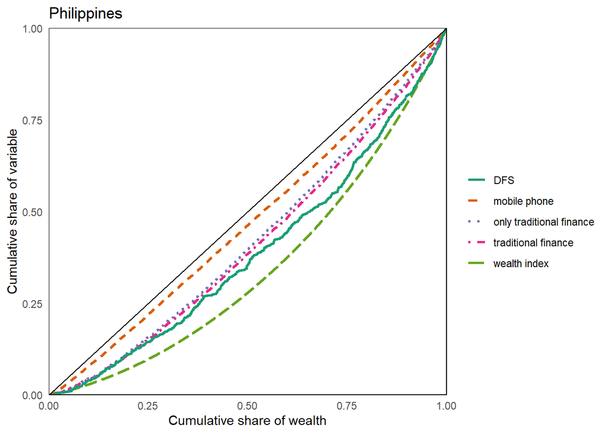

```r
# Individual level
indiv.lorenz.df <- dhs.indiv %>%
      arrange(wealth) %>%
    mutate(n= 1,
           wealth = wealth -min(wealth),
           cum_wealth=cumsum(wealth)/max(cumsum(wealth)),
           cum_phone=cumsum(own_phone)/max(cumsum(own_phone)),
           cum_trad_fin=cumsum(trad_fin)/max(cumsum(trad_fin)),
           cum_dfs=cumsum(mobile_dfs)/max(cumsum(mobile_dfs)),
           cum_pop=cumsum(n)/max(cumsum(n)),
           cum_only_trad=cumsum(only_trad_fin)/(max(cumsum(only_trad_fin))))

 # Combined individual concentration curves
  ggplot(indiv.lorenz.df, aes(size="test")) +
    geom_line(aes(x=cum_pop, y=cum_wealth, color="wealth index", linetype="wealth index")) +
    geom_line(aes(x=cum_pop, y=cum_phone, color="mobile phone", linetype="mobile phone")) +
    geom_line(aes(x=cum_pop, y=cum_trad_fin, color="traditional finance", linetype="traditional")) +
    geom_line(aes(x=cum_pop, y=cum_only_trad, color="only traditional finance", linetype="only traditional")) +
    geom_line(aes(x=cum_pop, y=cum_dfs, color="DFS", linetype="DFS")) +
    theme_minimal()+
    scale_color_brewer(name="", palette="Dark2") +
    scale_x_continuous(name="Cumulative share of wealth", limits=c(0,1), expand=c(0,0)) +
    scale_y_continuous(name="Cumulative share of variable", limits=c(0,1), expand=c(0,0)) +     scale_size_manual( values = 1, guide=FALSE) +
    scale_linetype_manual(name="", guide=FALSE, values=c(1, 2, 3, 4, 5))+
    labs(title="Philippines") +
    geom_abline() +
    guides(colour = guide_legend(override.aes = list(linetype = c(1, 2, 3, 4, 5), size=1))) +
    theme(panel.grid.major = element_line(colour = "transparent"), panel.grid.minor = element_blank(),
          panel.border = element_rect(colour = "black", fill=NA, size=.5)
)
```

# 3b. A Lack of Infrastructure Hurts Access to Traditional Finance and DFS

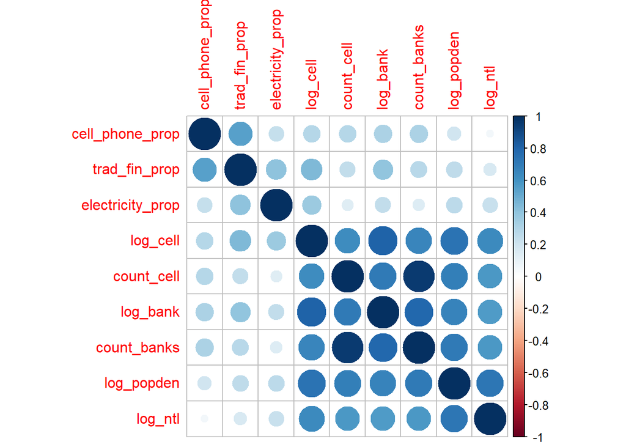

```r
## Alternative form of weights matrix
W.c<-as(as_dgRMatrix_listw(W), "CsparseMatrix")
trMat<-trW(W.c, type="mult")

## Graph correlation between key variables to look at multicollinearity
corrplot(cor(dplyr::select(dhs_indiv_sum, cell_phone_prop, trad_fin_prop, electricity_prop, log_cell, count_cell, log_bank, count_banks, log_popden, log_ntl)))
```

```r
## Descriptive statistics: cluster level
#stat.desc(dplyr::select(dhs_indiv_sum, cell_phone_prop, mobile_dfs_prop, trad_fin_prop, only_trad_prop, electricity_prop, log_cell, count_cell, log_bank, count_banks, log_popden, log_ntl, log_gsm, log_umts, log_lte, download))

desc <- sapply(seq(1:15), function(z){
    t<-dplyr::select(dhs_indiv_sum, cell_phone_prop, mobile_dfs_prop, trad_fin_prop, only_trad_prop, electricity_prop, log_cell, count_cell, log_bank, count_banks, log_popden, log_ntl, log_gsm, log_umts, log_lte, download)[,z] %>% unlist()
    c("mean" =mean(t, na.rm=T), "min" =min(t, na.rm=T), "max" = max(t,na.rm=T), "N"=length(na.omit(t)))
  })

colnames(desc) <- c("cell_phone_prop", "mobile_dfs_prop", "trad_fin_prop", "only_trad_prop", "electricity_prop", "log_cell", "count_cell", "log_bank", "count_banks", "log_popden", "log_ntl", "log_gsm", "log_umts", "log_lte", "download")

desc
```

```
##      cell_phone_prop mobile_dfs_prop trad_fin_prop only_trad_prop electricity_prop log_cell count_cell log_bank count_banks log_popden
## mean          0.7289         0.06323        0.4119         0.3758            0.904    3.466      565.4    1.491       45.86      5.886
## min           0.1111         0.00000        0.0000         0.0000            0.000    0.000        0.0    0.000        0.00      2.218
## max           1.0000         0.40909        0.8889         0.8148            1.000    9.154     9450.0    6.506      668.00     10.315
## N           383.0000       383.00000      383.0000       383.0000          383.000  383.000      383.0  383.000      383.00    383.000
##      log_ntl log_gsm log_umts  log_lte download
## mean   3.027   3.128    2.511   0.3053   13.780
## min    0.000   0.000    0.000   0.0000    2.372
## max    5.425   8.361    8.504   5.5334   47.098
## N    383.000 383.000  383.000 383.0000  375.000
```

## 3bi. Cluster-level models, base specification

```r
base_controls <- c("electricity_prop", "log_cell", "log_bank", "log_popden", "log_ntl")

## Download speed predicted by infrastructure
download.lm <- lm(paste("download~", paste(base_controls, collapse="+")), data = dhs_indiv_sum)
coeftest(download.lm, vcov = vcovHC(download.lm, type="HC1"))
```

```
##
## t test of coefficients:
##
##                  Estimate Std. Error t value Pr(>|t|)
## (Intercept)       13.9968     2.0907    6.69  8.1e-11 ***
## electricity_prop  -3.9088     1.5727   -2.49    0.013 *
## log_cell           0.9460     0.2330    4.06  6.0e-05 ***
## log_bank          -0.0482     0.2171   -0.22    0.824
## log_popden        -0.2481     0.2958   -0.84    0.402
## log_ntl            0.5086     0.3634    1.40    0.162
## ---
## Signif. codes:  0 '***' 0.001 '**' 0.01 '*' 0.05 '.' 0.1 ' ' 1
```

```r
nobs(download.lm)
```

```
## [1] 375
```

```r
summary(download.lm)$r.squared
```

```
## [1] 0.1862
```

```r
## Phone ownership
cell.lm <- lm(paste("cell_phone_prop~", paste(base_controls, collapse="+")), data = dhs_indiv_sum)
coeftest(cell.lm, vcov = vcovHC(cell.lm, type="HC1"))
```

```
##
## t test of coefficients:
##
##                  Estimate Std. Error t value Pr(>|t|)
## (Intercept)       0.63655    0.06197   10.27  < 2e-16 ***
## electricity_prop  0.13333    0.04983    2.68  0.00778 **
## log_cell          0.00819    0.00632    1.30  0.19521
## log_bank          0.02660    0.00784    3.39  0.00077 ***
## log_popden        0.00780    0.01069    0.73  0.46597
## log_ntl          -0.04695    0.01447   -3.25  0.00128 **
## ---
## Signif. codes:  0 '***' 0.001 '**' 0.01 '*' 0.05 '.' 0.1 ' ' 1
```

```r
nobs(cell.lm)
```

```
## [1] 383
```

```r
summary(cell.lm)$r.squared
```

```
## [1] 0.1618
```

```r
## DFS
dfsuse.lm <- lm(paste("mobile_dfs_prop~", paste(base_controls, collapse="+")), data = dhs_indiv_sum)
coeftest(dfsuse.lm, vcov = vcovHC(dfsuse.lm, type="HC1"))
```

```
##
## t test of coefficients:
##
##                  Estimate Std. Error t value Pr(>|t|)
## (Intercept)       0.02044    0.02161    0.95  0.34486
## electricity_prop  0.04309    0.01376    3.13  0.00188 **
## log_cell          0.00296    0.00250    1.18  0.23763
## log_bank          0.01157    0.00306    3.78  0.00018 ***
## log_popden        0.00167    0.00456    0.37  0.71524
## log_ntl          -0.01106    0.00552   -2.00  0.04580 *
## ---
## Signif. codes:  0 '***' 0.001 '**' 0.01 '*' 0.05 '.' 0.1 ' ' 1
```

```r
nobs(dfsuse.lm)
```

```
## [1] 383
```

```r
summary(dfsuse.lm)$r.squared
```

```
## [1] 0.1514
```

```r
## Traditional finance
tradfin.lm <- lm(paste("trad_fin_prop~", paste(base_controls, collapse="+")), data = dhs_indiv_sum)
coeftest(tradfin.lm, vcov = vcovHC(tradfin.lm, type="HC1"))
```

```
##
## t test of coefficients:
##
##                  Estimate Std. Error t value Pr(>|t|)
## (Intercept)       0.20531    0.04832    4.25  2.7e-05 ***
## electricity_prop  0.27180    0.03817    7.12  5.5e-12 ***
## log_cell          0.02804    0.00718    3.91  0.00011 ***
## log_bank          0.01863    0.00764    2.44  0.01525 *
## log_popden       -0.00857    0.00989   -0.87  0.38667
## log_ntl          -0.03755    0.01442   -2.60  0.00956 **
## ---
## Signif. codes:  0 '***' 0.001 '**' 0.01 '*' 0.05 '.' 0.1 ' ' 1
```

```r
nobs(tradfin.lm)
```

```
## [1] 383
```

```r
summary(tradfin.lm)$r.squared
```

```
## [1] 0.2998
```

```r
## Only traditional finance
only_tradfin.lm <- lm(paste("only_trad_prop~", paste(base_controls, collapse="+")), data = dhs_indiv_sum)
coeftest(only_tradfin.lm, vcov = vcovHC(only_tradfin.lm, type="HC1"))
```

```
##
## t test of coefficients:
##
##                  Estimate Std. Error t value Pr(>|t|)
## (Intercept)       0.20388    0.04556    4.47  1.0e-05 ***
## electricity_prop  0.23864    0.03509    6.80  4.1e-11 ***
## log_cell          0.02619    0.00681    3.85  0.00014 ***
## log_bank          0.00913    0.00722    1.26  0.20721
## log_popden       -0.00858    0.00940   -0.91  0.36169
## log_ntl          -0.03227    0.01406   -2.30  0.02221 *
## ---
## Signif. codes:  0 '***' 0.001 '**' 0.01 '*' 0.05 '.' 0.1 ' ' 1
```

```r
nobs(only_tradfin.lm)
```

```
## [1] 383
```

```r
summary(only_tradfin.lm)$r.squared
```

```
## [1] 0.25
```

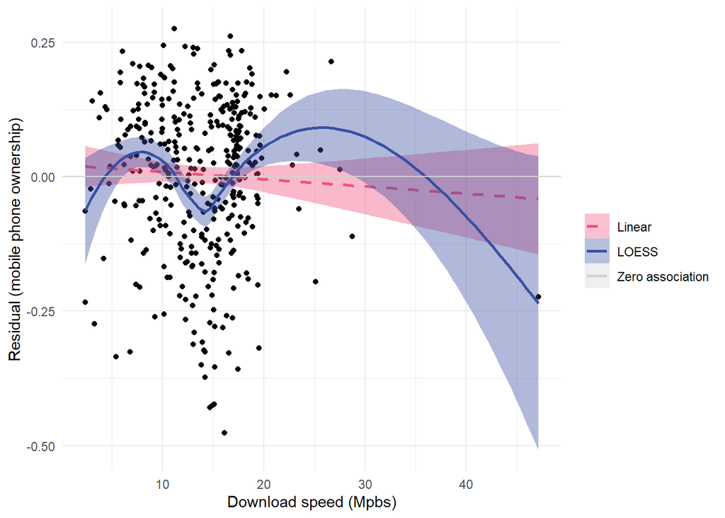

```r
# Plot residuals against download speed
graph_residuals <- function(model, title) {

graph_data <- cbind(dhs_indiv_sum$download[!is.na(dhs_indiv_sum$download)], model$residuals[!is.na(dhs_indiv_sum$download)]) %>% as.data.frame()
ggplot(data=graph_data, aes(x=V1, y=V2)) +
  geom_point() +
  geom_smooth(aes(color="Linear fit", fill="Linear"), method="lm", linetype="dashed") +
  geom_smooth(aes(color="LOESS fit", fill="LOESS"), method="loess") +
  geom_hline(aes(yintercept=0, color="Zero association", fill="Zero association")) +
  scale_color_manual(values=c("Linear fit" = "#f0517e", "LOESS fit" = "#3950a3", "Zero association" = "lightgray"), guide="none") +
  scale_fill_manual(name="", values=c("Linear" = "#f0517e", "LOESS" = "#3950a3", "Zero association" = "lightgray"), guide=guide_legend(override.aes=list(alpha=0.2, color=c("#f0517e", "#3950a3", "lightgray"), linetype=c("dashed", "solid", "solid")))) +
  labs(x="Download speed (Mpbs)", y=paste0("Residual (", title, ")")) +
theme_minimal()
}

graph_residuals(cell.lm, "mobile phone ownership")
```

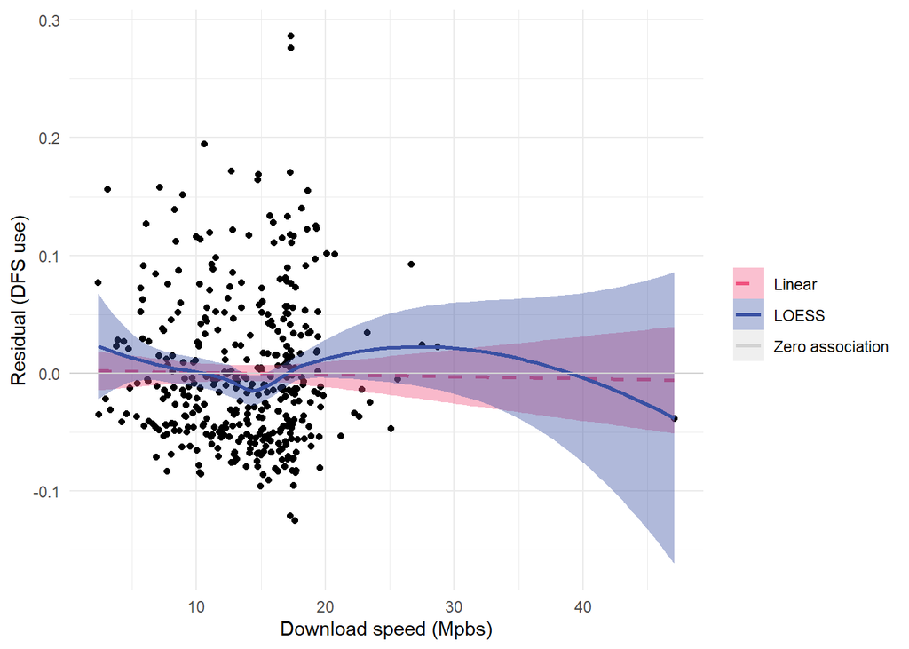

```r
graph_residuals(dfsuse.lm, "DFS use")
```

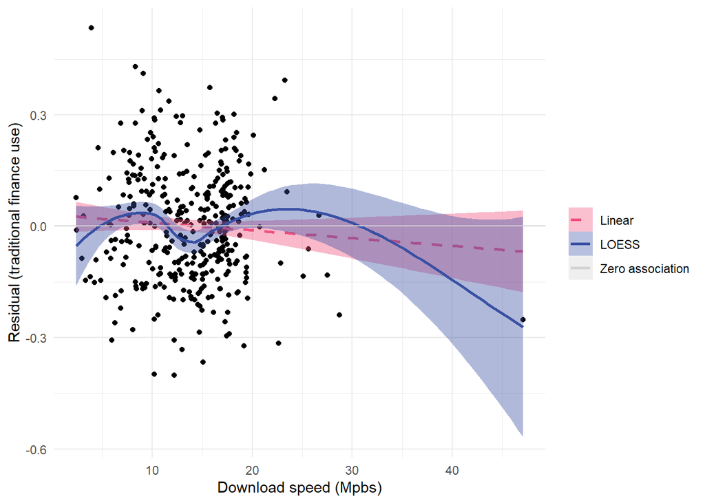

```r
graph_residuals(tradfin.lm, "traditional finance use")
```

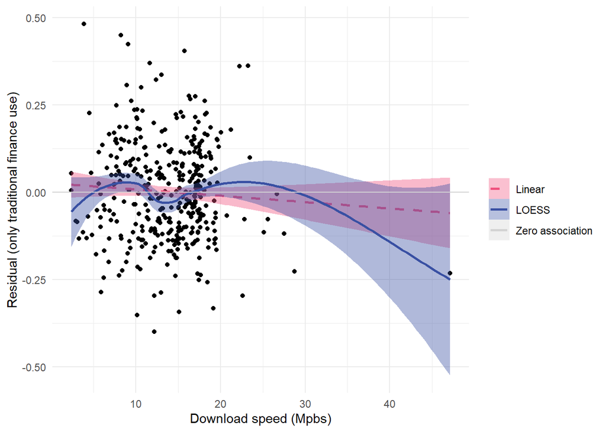

```r
graph_residuals(only_tradfin.lm, "only traditional finance use")
```

## 3bi. Cluster-level models, type of tower

```r
base_controls <- c("electricity_prop", "log_gsm", "log_umts", "log_lte", "log_bank", "log_popden", "log_ntl")

## Download speed predicted by infrastructure
download.lm <- lm(paste("download~", paste(base_controls, collapse="+")), data = dhs_indiv_sum)
coeftest(download.lm, vcov = vcovHC(download.lm, type="HC1"))
```

```
##
## t test of coefficients:
##
##                  Estimate Std. Error t value     Pr(>|t|)
## (Intercept)      13.59531    2.29989    5.91 0.0000000078 ***
## electricity_prop -4.07541    1.55297   -2.62      0.00905 **
## log_gsm           0.40954    0.36808    1.11      0.26660
## log_umts          0.70551    0.30963    2.28      0.02327 *
## log_lte          -0.57411    0.15357   -3.74      0.00021 ***
## log_bank         -0.00509    0.20478   -0.02      0.98020
## log_popden       -0.09123    0.33618   -0.27      0.78625
## log_ntl           0.49773    0.36281    1.37      0.17093
## ---
## Signif. codes:  0 '***' 0.001 '**' 0.01 '*' 0.05 '.' 0.1 ' ' 1
```

```r
nobs(download.lm)
```

```
## [1] 375
```

```r
summary(download.lm)$r.squared
```

```
## [1] 0.1968
```

```r
## Phone ownership
cell.lm <- lm(paste("cell_phone_prop~", paste(base_controls, collapse="+")), data = dhs_indiv_sum)
coeftest(cell.lm, vcov = vcovHC(cell.lm, type="HC1"))
```

```
##
## t test of coefficients:
##
##                    Estimate Std. Error t value Pr(>|t|)
## (Intercept)       0.6807571  0.0670286   10.16  < 2e-16 ***
## electricity_prop  0.1445728  0.0513611    2.81  0.00514 **
## log_gsm           0.0129700  0.0105800    1.23  0.22101
## log_umts         -0.0036343  0.0101940   -0.36  0.72166
## log_lte           0.0255794  0.0075518    3.39  0.00078 ***
## log_bank          0.0196143  0.0084231    2.33  0.02041 *
## log_popden        0.0000944  0.0117375    0.01  0.99359
## log_ntl          -0.0500661  0.0142109   -3.52  0.00048 ***
## ---
## Signif. codes:  0 '***' 0.001 '**' 0.01 '*' 0.05 '.' 0.1 ' ' 1
```

```r
nobs(cell.lm)
```

```
## [1] 383
```

```r
summary(cell.lm)$r.squared
```

```
## [1] 0.1808
```

```r
## DFS
dfsuse.lm <- lm(paste("mobile_dfs_prop~", paste(base_controls, collapse="+")), data = dhs_indiv_sum)
coeftest(dfsuse.lm, vcov = vcovHC(dfsuse.lm, type="HC1"))
```

```
##
## t test of coefficients:
##
##                    Estimate Std. Error t value Pr(>|t|)
## (Intercept)       0.0453270  0.0203612    2.23  0.02660 *
## electricity_prop  0.0494442  0.0137261    3.60  0.00036 ***
## log_gsm           0.0038050  0.0045325    0.84  0.40173
## log_umts         -0.0000264  0.0051471   -0.01  0.99591
## log_lte           0.0135547  0.0052441    2.58  0.01012 *
## log_bank          0.0074471  0.0033861    2.20  0.02846 *
## log_popden       -0.0025954  0.0042044   -0.62  0.53741
## log_ntl          -0.0127477  0.0053019   -2.40  0.01668 *
## ---
## Signif. codes:  0 '***' 0.001 '**' 0.01 '*' 0.05 '.' 0.1 ' ' 1
```

```r
nobs(dfsuse.lm)
```

```
## [1] 383
```

```r
summary(dfsuse.lm)$r.squared
```

```
## [1] 0.1812
```

```r
## Traditional finance
tradfin.lm <- lm(paste("trad_fin_prop~", paste(base_controls, collapse="+")), data = dhs_indiv_sum)
coeftest(tradfin.lm, vcov = vcovHC(tradfin.lm, type="HC1"))
```

```
##
## t test of coefficients:
##
##                   Estimate Std. Error t value Pr(>|t|)
## (Intercept)       0.200731   0.052713    3.81  0.00016 ***
## electricity_prop  0.272292   0.039257    6.94  1.8e-11 ***
## log_gsm           0.034182   0.011413    3.00  0.00293 **
## log_umts         -0.006003   0.011446   -0.52  0.60026
## log_lte           0.000688   0.007954    0.09  0.93110
## log_bank          0.020764   0.008228    2.52  0.01203 *
## log_popden       -0.007223   0.010477   -0.69  0.49096
## log_ntl          -0.038147   0.014455   -2.64  0.00866 **
## ---
## Signif. codes:  0 '***' 0.001 '**' 0.01 '*' 0.05 '.' 0.1 ' ' 1
```

```r
nobs(tradfin.lm)
```

```
## [1] 383
```

```r
summary(tradfin.lm)$r.squared
```

```
## [1] 0.3002
```

```r
## Only traditional finance
only_tradfin.lm <- lm(paste("only_trad_prop~", paste(base_controls, collapse="+")), data = dhs_indiv_sum)
coeftest(only_tradfin.lm, vcov = vcovHC(only_tradfin.lm, type="HC1"))
```

```
##
## t test of coefficients:
##
##                  Estimate Std. Error t value Pr(>|t|)
## (Intercept)       0.17997    0.04898    3.67  0.00027 ***
## electricity_prop  0.23365    0.03572    6.54    2e-10 ***
## log_gsm           0.03203    0.01041    3.08  0.00225 **
## log_umts         -0.00608    0.01040   -0.58  0.55944
## log_lte          -0.01015    0.00697   -1.46  0.14607
## log_bank          0.01441    0.00772    1.87  0.06257 .
## log_popden       -0.00391    0.00976   -0.40  0.68939
## log_ntl          -0.03162    0.01398   -2.26  0.02433 *
## ---
## Signif. codes:  0 '***' 0.001 '**' 0.01 '*' 0.05 '.' 0.1 ' ' 1
```

```r
nobs(only_tradfin.lm)
```

```
## [1] 383
```

```r
summary(only_tradfin.lm)$r.squared
```

```
## [1] 0.2537
```

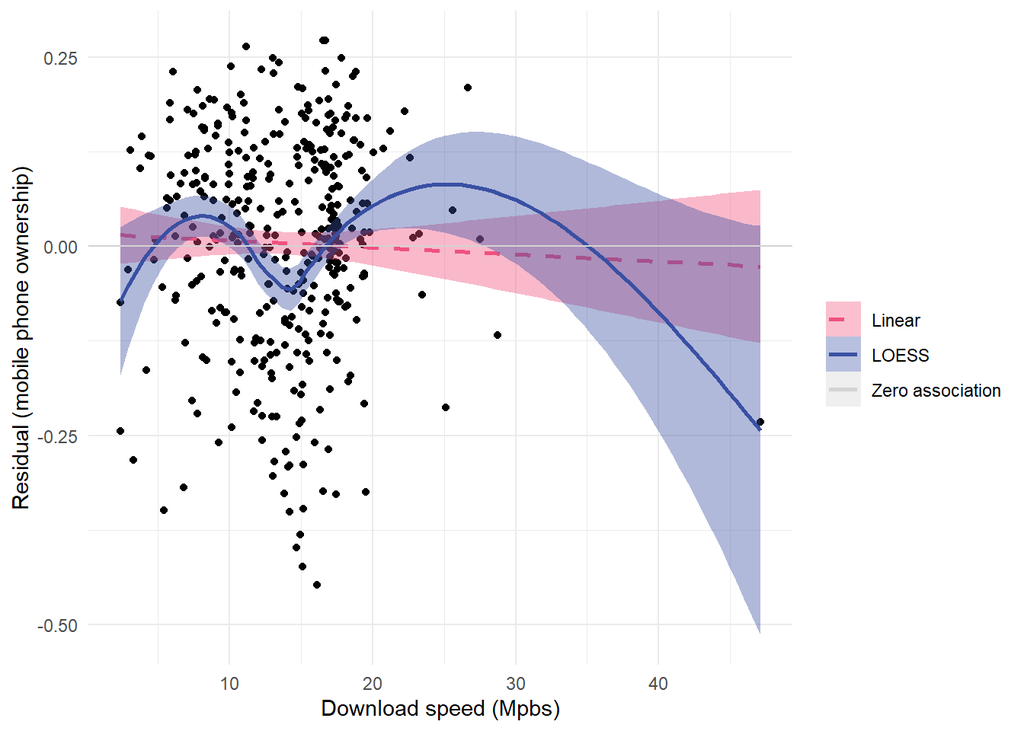

```r
# Plot residuals against download speed
graph_residuals(cell.lm, "mobile phone ownership")
```

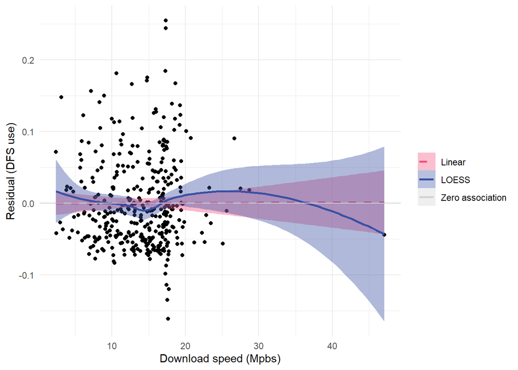

```r
graph_residuals(dfsuse.lm, "DFS use")
```

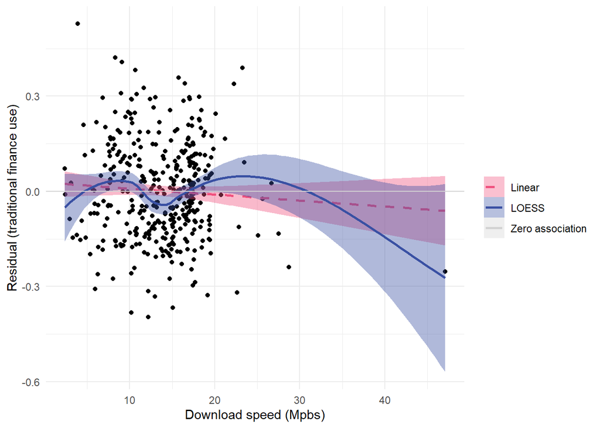

```r
graph_residuals(tradfin.lm, "traditional finance use")
```

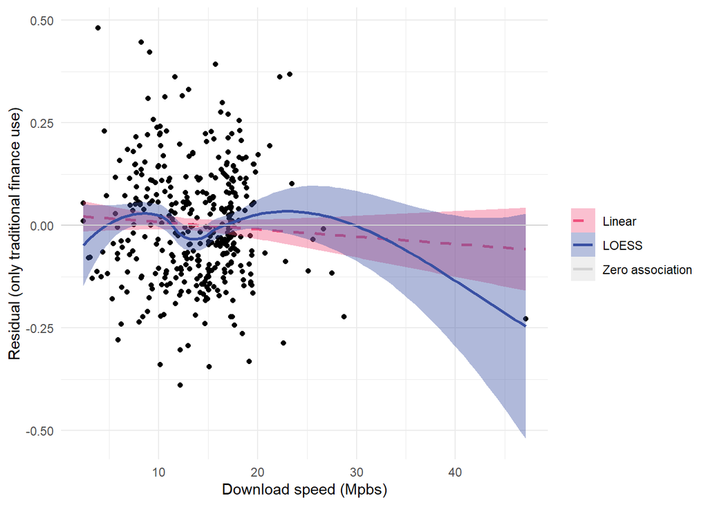

```r
graph_residuals(only_tradfin.lm, "only traditional finance use")
```

## 3bii. Cluster-level models, control for download speed

```r
base_controls <- c("electricity_prop", "log_cell", "download", "log_bank", "log_popden", "log_ntl")

## Phone ownership
cell.lm <- lm(paste("cell_phone_prop~", paste(base_controls, collapse="+")), data = dhs_indiv_sum)
coeftest(cell.lm, vcov = vcovHC(cell.lm, type="HC1"))
```

```
##
## t test of coefficients:
##
##                  Estimate Std. Error t value Pr(>|t|)
## (Intercept)       0.72000    0.05587   12.89  < 2e-16 ***
## electricity_prop  0.11243    0.04278    2.63   0.0089 **
## log_cell          0.00540    0.00630    0.86   0.3920
## download         -0.00125    0.00177   -0.70   0.4834
## log_bank          0.03304    0.00756    4.37 0.000016 ***
## log_popden       -0.00570    0.00880   -0.65   0.5174
## log_ntl          -0.03476    0.01323   -2.63   0.0089 **
## ---
## Signif. codes:  0 '***' 0.001 '**' 0.01 '*' 0.05 '.' 0.1 ' ' 1
```

```r
nobs(cell.lm)
```

```
## [1] 375
```

```r
summary(cell.lm)$r.squared
```

```
## [1] 0.1503
```

```r
## DFS
dfsuse.lm <- lm(paste("mobile_dfs_prop~", paste(base_controls, collapse="+")), data = dhs_indiv_sum)
coeftest(dfsuse.lm, vcov = vcovHC(dfsuse.lm, type="HC1"))
```

```
##
## t test of coefficients:
##
##                   Estimate Std. Error t value Pr(>|t|)
## (Intercept)       0.019414   0.024889    0.78  0.43589
## electricity_prop  0.050102   0.015772    3.18  0.00162 **
## log_cell          0.002607   0.002630    0.99  0.32213
## download         -0.000163   0.000658   -0.25  0.80417
## log_bank          0.012095   0.003102    3.90  0.00012 ***
## log_popden        0.000565   0.004839    0.12  0.90704
## log_ntl          -0.009759   0.005743   -1.70  0.09013 .
## ---
## Signif. codes:  0 '***' 0.001 '**' 0.01 '*' 0.05 '.' 0.1 ' ' 1
```

```r
nobs(dfsuse.lm)
```

```
## [1] 375
```

```r
summary(dfsuse.lm)$r.squared
```

```
## [1] 0.1493
```

```r
## Traditional finance
tradfin.lm <- lm(paste("trad_fin_prop~", paste(base_controls, collapse="+")), data = dhs_indiv_sum)
coeftest(tradfin.lm, vcov = vcovHC(tradfin.lm, type="HC1"))
```

```
##
## t test of coefficients:
##
##                  Estimate Std. Error t value     Pr(>|t|)
## (Intercept)       0.25881    0.05580    4.64 0.0000048983 ***
## electricity_prop  0.26494    0.04274    6.20 0.0000000015 ***
## log_cell          0.02777    0.00750    3.70      0.00025 ***
## download         -0.00232    0.00208   -1.12      0.26456
## log_bank          0.02186    0.00765    2.86      0.00448 **
## log_popden       -0.01516    0.00999   -1.52      0.12983
## log_ntl          -0.03043    0.01425   -2.14      0.03340 *
## ---
## Signif. codes:  0 '***' 0.001 '**' 0.01 '*' 0.05 '.' 0.1 ' ' 1
```

```r
nobs(tradfin.lm)
```

```
## [1] 375
```

```r
summary(tradfin.lm)$r.squared
```

```
## [1] 0.2816
```

```r
## Only traditional finance
only_tradfin.lm <- lm(paste("only_trad_prop~", paste(base_controls, collapse="+")), data = dhs_indiv_sum)
coeftest(only_tradfin.lm, vcov = vcovHC(only_tradfin.lm, type="HC1"))
```

```
##
## t test of coefficients:
##
##                  Estimate Std. Error t value     Pr(>|t|)
## (Intercept)       0.25646    0.05177    4.95 0.0000011119 ***
## electricity_prop  0.22801    0.03847    5.93 0.0000000071 ***
## log_cell          0.02595    0.00706    3.68      0.00027 ***
## download         -0.00203    0.00194   -1.05      0.29595
## log_bank          0.01214    0.00724    1.68      0.09420 .
## log_popden       -0.01465    0.00954   -1.54      0.12542
## log_ntl          -0.02601    0.01396   -1.86      0.06318 .
## ---
## Signif. codes:  0 '***' 0.001 '**' 0.01 '*' 0.05 '.' 0.1 ' ' 1
```

```r
nobs(only_tradfin.lm)
```

```
## [1] 375
```

```r
summary(only_tradfin.lm)$r.squared
```

```
## [1] 0.2287
```

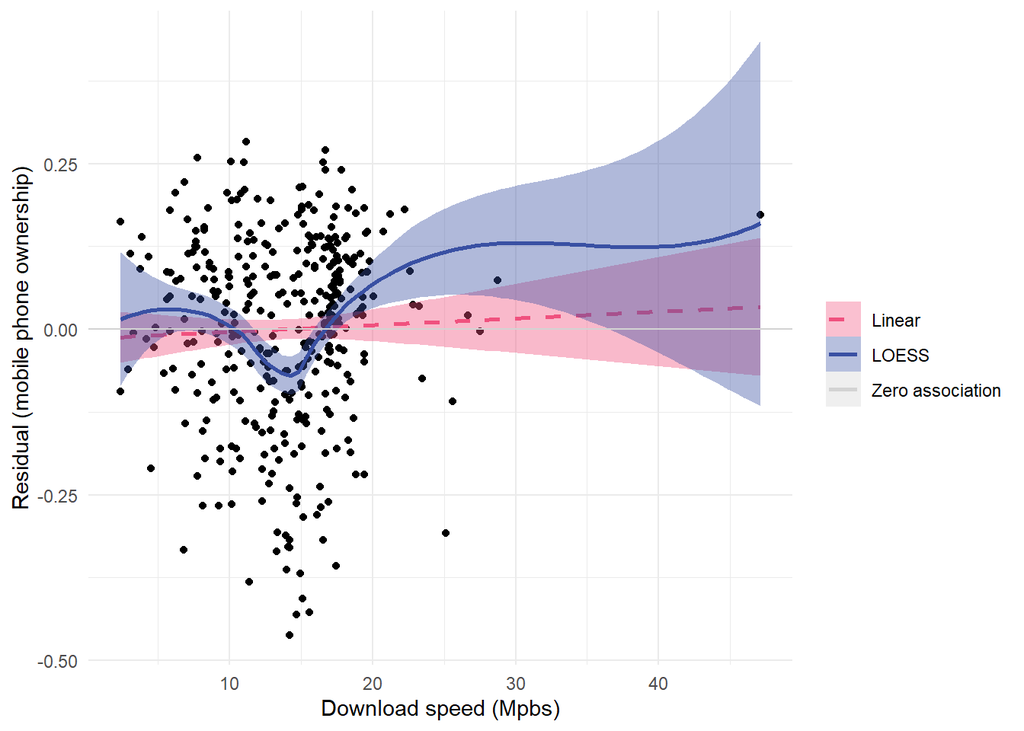

```r
# Plot residuals against download speed
graph_residuals(cell.lm, "mobile phone ownership")
```

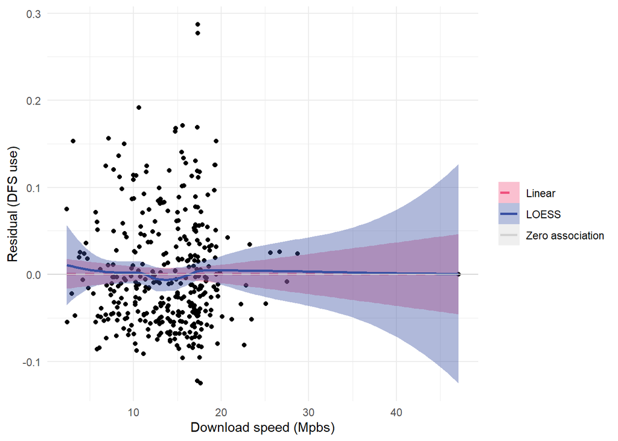

```r
graph_residuals(dfsuse.lm, "DFS use")
```

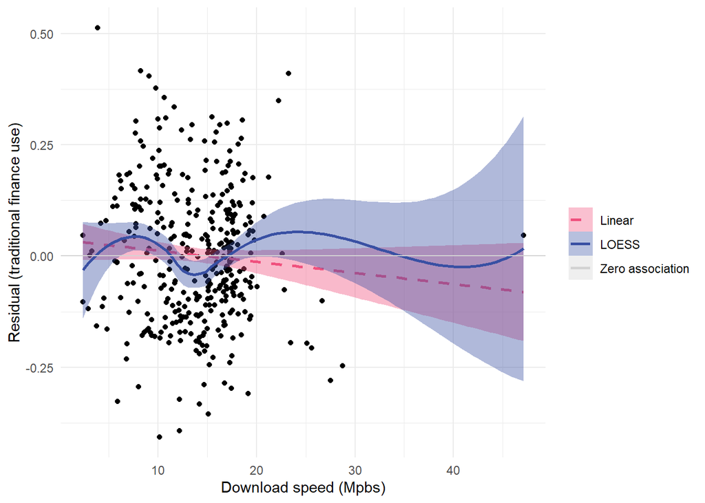

```r
graph_residuals(tradfin.lm, "traditional finance use")
```

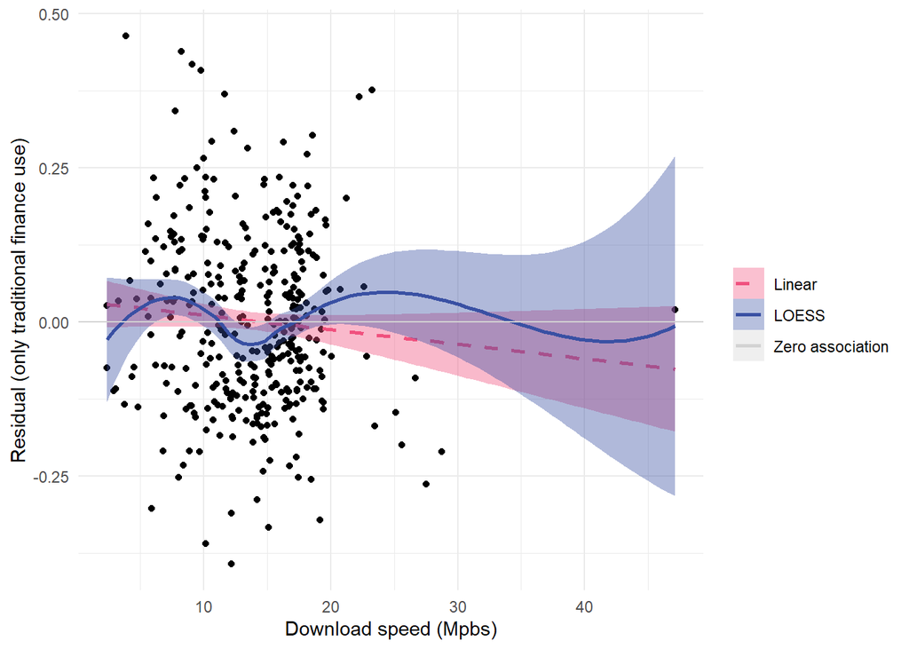

```r
graph_residuals(only_tradfin.lm, "only traditional finance use")
```

# 3c: Individual Factors Determining Use

```r
# Descriptive statistics
dhs.indiv <- dhs.indiv %>% dummy_cols("wealth_index")

# stat.desc(dplyr::select(dhs.indiv, own_phone, mobile_dfs, trad_fin, log_cell, log_gsm, log_umts, log_lte, download, log_bank, age, urban, children, eduyears, hhhmale, married, wealth_index_1, wealth_index_2, wealth_index_3, wealth_index_4, wealth_index_5 ))

desc <- sapply(seq(1:20), function(z){
    t<-dplyr::select(dhs.indiv, own_phone, mobile_dfs, trad_fin, log_cell, log_gsm, log_umts, log_lte, download, log_bank, age, urban, children, eduyears, hhhmale, married, wealth_index_1, wealth_index_2, wealth_index_3, wealth_index_4, wealth_index_5) %>% filter(!is.na(log_cell))
    t <- t[,z] %>% unlist()
    c("mean" =mean(t, na.rm=T), "min" =min(t, na.rm=T), "max" = max(t,na.rm=T), "N"=length(na.omit(t)))
  })

colnames(desc) <- c("own_phone", "mobile_dfs", "trad_fin", "log_cell", "log_gsm", "log_umts", "log_lte", "download", "log_bank", "age", "urban", "children", "eduyears", "hhhmale", "married", "wealth_index_1", "wealth_index_2", "wealth_index_3", "wealth_index_4", "wealth_index_5")

desc
```

```
##       own_phone  mobile_dfs   trad_fin  log_cell   log_gsm  log_umts    log_lte  download  log_bank      age      urban  children
## mean     0.7178     0.06032     0.4028     3.443     3.112     2.455     0.2501    13.853     1.432    29.51     0.6436     2.068
## min      0.0000     0.00000     0.0000     0.000     0.000     0.000     0.0000     2.372     0.000    15.00     0.0000     0.000
## max      1.0000     1.00000     1.0000     9.154     8.361     8.504     5.5334    47.098     6.506    49.00     1.0000    15.000
## N    12268.0000 12268.00000 12268.0000 12268.000 12268.000 12268.000 12268.0000 12024.000 12268.000 12268.00 12268.0000 12268.000
##       eduyears    hhhmale    married wealth_index_1 wealth_index_2 wealth_index_3 wealth_index_4 wealth_index_5
## mean     5.073     0.6777     0.7697         0.2248         0.2218         0.2058         0.1796          0.168
## min      0.000     0.0000     0.0000         0.0000         0.0000         0.0000         0.0000          0.000
## max     11.000     1.0000     1.0000         1.0000         1.0000         1.0000         1.0000          1.000
## N    12268.000 12268.0000 12268.0000     12268.0000     12268.0000     12268.0000     12268.0000      12268.000
```

```r
# Define a function to handle the regressions and make it easier
logit.custom <- function(y, controls, filter=F){

  if(filter ==T){
    data <- filter(dhs.indiv, own_phone==1)
  } else{
    data <- dhs.indiv
  }

  f <- as.formula(paste(y, "~", paste(controls, collapse="+")))
  logit <- glm(f, data=data, family = "binomial")
  null.logit <- glm(f=as.formula(paste(y, "~1")), data=model.frame(logit), family="binomial")
  v <- vcovCL(logit, type="HC1", cluster = ~v001)
  m <- margins(logit, vcov=v, data=data)
  meffects <- apply(marginal_effects(logit),2, FUN=mean)
  meffects <- meffects[order(names(meffects))]
  mvar <-apply(dplyr::select(m, starts_with("Var")), 2, FUN=function(x) mean(x, na.rm=T))
  mvar <- mvar[order(names(meffects))]
  mse <- sqrt(mvar)
  df <- length(data) -length(controls)
  mpvalue <- 1- pt(abs(meffects)/mse, df)
  tidymodel <- tidy(logit)
  tidymodel <- tidymodel[order(tidymodel$term), ]
  tidymodel$clusteredse <- sqrt(diag(v))
  tidymodel$meffects <- NA
  tidymodel$mse <- NA
  tidymodel$mpvalue <-NA
  tidymodel$meffects[2:nrow(tidymodel)] <-meffects
  tidymodel$mse[2:nrow(tidymodel)] <-mse
  tidymodel$mpvalue[2:nrow(tidymodel)] <- mpvalue
  tidymodel$mcfadden <- 1- logLik(logit)/logLik(null.logit)
  tidymodel$N <- nobs(logit)

  return(list(logit, v, tidymodel))
}


## Individual characteristics with location characteristics
full.controls <- c("age", "age2", "urban", "children", "eduyears", "hhhmale", "region", "own_land", "married", "log_cell", "log_bank", "wealth_index_2", "wealth_index_3", "wealth_index_4", "wealth_index_5")

phone.logit.loc <- logit.custom("own_phone", full.controls, filter=F)
dfs.logit.loc <- logit.custom("mobile_dfs", full.controls, filter=T)
trad_fin.logit.loc <- logit.custom("trad_fin", full.controls, filter=T)
trad_fin_fil.logit.loc <- logit.custom("trad_fin", full.controls, filter=F)
only_trad_fin.logit.loc <- logit.custom("only_trad_fin", full.controls, filter=F)

stargazer(list(phone.logit.loc[[1]], dfs.logit.loc[[1]], trad_fin.logit.loc[[1]], trad_fin_fil.logit.loc[[1]], only_trad_fin.logit.loc[[1]]),
           se = list(sqrt(diag(phone.logit.loc[[2]])), sqrt(diag(dfs.logit.loc[[2]])), sqrt(diag(trad_fin.logit.loc[[2]])), sqrt(diag(trad_fin_fil.logit.loc[[2]])), sqrt(diag(only_trad_fin.logit.loc[[2]]))),
           type="text")
```

```
##
## ===========================================================================
##                                      Dependent variable:
##                   ---------------------------------------------------------
##                   own_phone  mobile_dfs       trad_fin        only_trad_fin
##                      (1)        (2)        (3)        (4)          (5)
## ---------------------------------------------------------------------------
## age                0.420***   -0.069*    0.395***   0.413***    0.387***
##                    (0.020)    (0.038)    (0.023)    (0.020)      (0.020)
##
## age2              -0.006***    0.001    -0.005***  -0.005***    -0.005***
##                    (0.0003)   (0.001)    (0.0004)   (0.0003)    (0.0003)
##
## urban              0.258***    0.063     0.504***   0.486***    0.448***
##                    (0.082)    (0.132)    (0.082)    (0.075)      (0.075)
##
## children          -0.172***  -0.155***   0.049**     0.002        0.008
##                    (0.021)    (0.058)    (0.024)    (0.019)      (0.018)
##
## eduyears           0.195***   0.171***   0.095***   0.105***    0.066***
##                    (0.009)    (0.018)    (0.009)    (0.008)      (0.008)
##
## hhhmale           -0.844***    -0.100   -0.343***  -0.426***    -0.366***
##                    (0.056)    (0.088)    (0.054)    (0.048)      (0.048)
##
## region2             -0.051     -0.054   -0.542***  -0.582***    -0.570***
##                    (0.131)    (0.244)    (0.141)    (0.117)      (0.117)
##
## region3            0.532***    0.300     0.375***   0.351**       0.199
##                    (0.129)    (0.185)    (0.144)    (0.144)      (0.142)
##
## region4            0.678***    0.254     0.312**    0.370***     0.289**
##                    (0.147)    (0.176)    (0.121)    (0.113)      (0.117)
##
## region5             -0.091    -0.335*     -0.145    -0.192*      -0.163
##                    (0.116)    (0.197)    (0.119)    (0.107)      (0.111)
##
## region6             0.210*     0.143      0.011      -0.023      -0.107
##                    (0.122)    (0.201)    (0.150)    (0.143)      (0.142)
##
```

[output cut: 21 more lines]

```
## wealth_index_4     0.470***    0.337*    0.955***   0.901***    0.844***
##                    (0.092)    (0.193)    (0.111)    (0.100)      (0.098)
##
## wealth_index_5     0.590***    0.407*    1.220***   1.201***    1.047***
##                    (0.108)    (0.216)    (0.131)    (0.117)      (0.112)
##
## Constant          -6.385***  -2.667***  -8.776***  -9.195***    -8.630***
##                    (0.313)    (0.575)    (0.382)    (0.320)      (0.320)
##
## ---------------------------------------------------------------------------
## Observations        12,268     8,806      8,806      12,268      12,268
## Log Likelihood    -5,918.000 -2,285.000 -5,017.000 -6,695.000  -6,770.000
## Akaike Inf. Crit. 11,879.000 4,612.000  10,077.000 13,432.000  13,581.000
## ===========================================================================
## Note:                                           *p<0.1; **p<0.05; ***p<0.01
```

```r
l <- list(phone.logit.loc, dfs.logit.loc, trad_fin_fil.logit.loc, only_trad_fin.logit.loc)
for (model in seq(1, 4)){
  model <- l[[model]]
  print(cbind(model[[3]]$term, model[[3]]$meffects, model[[3]]$mse, model[[3]]$mpvalue))
  print(mean(model[[3]]$N))
  print(mean(model[[3]]$mcfadden))
}
```

```
##       [,1]             [,2]                    [,3]                    [,4]
##  [1,] "(Intercept)"    NA                      NA                      NA
##  [2,] "age"            "0.0668759249140969"    "0.0030631966163496"    "0"
##  [3,] "age2"           "-0.000992757354432549" "0.0000449025139290631" "0"
##  [4,] "children"       "-0.027356658234511"    "0.013040278980043"     "0.0202629928309784"
##  [5,] "eduyears"       "0.0310668045628427"    "0.00336888397998487"   "4.68070027181966e-13"
##  [6,] "hhhmale"        "-0.134569357108234"    "0.0014238475133699"    "0"
##  [7,] "log_bank"       "0.0046443904667736"    "0.00874781927526145"   "0.298805930225344"
##  [8,] "log_cell"       "-0.0126901619356623"   "0.0141035921512606"    "0.186079471627838"
##  [9,] "married"        "0.157288157859863"     "0.0114619732236837"    "0"
## [10,] "own_land"       "0.0613012703120894"    "0.00496041152267902"   "0"
## [11,] "region2"        "-0.00851399644048244"  "0.00641171176820994"   "0.0948509371006253"
## [12,] "region3"        "0.082103220640847"     "0.011401858055808"     "8.83927375738836e-10"
## [13,] "region4"        "0.102104193721685"     "0.0130857203205996"    "9.14892606118656e-11"
## [14,] "region5"        "-0.0153718963887938"   "0.0145231357870082"    "0.147240280566772"
```

[output cut: 81 more lines]

```r
## Individual characteristics with download speed control
full.controls <- c("age", "age2", "urban", "children", "eduyears", "hhhmale", "region", "own_land", "married", "log_gsm", "log_umts", "log_lte", "log_bank", "wealth_index_2", "wealth_index_3", "wealth_index_4", "wealth_index_5", "download")

phone.logit.loc2 <- logit.custom("own_phone", full.controls, filter=F)
dfs.logit.loc2 <- logit.custom("mobile_dfs", full.controls, filter=T)
trad_fin.logit.loc2 <- logit.custom("trad_fin", full.controls, filter=T)
trad_fin_fil.logit.loc2 <- logit.custom("trad_fin", full.controls, filter=F)
only_trad_fin.logit.loc2 <- logit.custom("only_trad_fin", full.controls, filter=F)

stargazer(list(phone.logit.loc2[[1]], dfs.logit.loc2[[1]], trad_fin.logit.loc2[[1]], trad_fin_fil.logit.loc2[[1]], only_trad_fin.logit.loc2[[1]]),
           se = list(sqrt(diag(phone.logit.loc2[[2]])), sqrt(diag(dfs.logit.loc2[[2]])), sqrt(diag(trad_fin.logit.loc2[[2]])), sqrt(diag(trad_fin_fil.logit.loc2[[2]])), sqrt(diag(only_trad_fin.logit.loc2[[2]]))),
           type="text")
```

```
##
## ===========================================================================
##                                      Dependent variable:
##                   ---------------------------------------------------------
##                   own_phone  mobile_dfs       trad_fin        only_trad_fin
##                      (1)        (2)        (3)        (4)          (5)
## ---------------------------------------------------------------------------
## age                0.430***   -0.067*    0.402***   0.420***    0.393***
##                    (0.020)    (0.038)    (0.023)    (0.020)      (0.020)
##
## age2              -0.006***    0.001    -0.005***  -0.005***    -0.005***
##                    (0.0003)   (0.001)    (0.0004)   (0.0003)    (0.0003)
##
## urban              0.260***    0.059     0.463***   0.446***    0.406***
##                    (0.078)    (0.135)    (0.083)    (0.076)      (0.076)
##
## children          -0.177***  -0.155***   0.050**     0.005        0.010
##                    (0.021)    (0.058)    (0.024)    (0.020)      (0.019)
##
## eduyears           0.190***   0.169***   0.097***   0.104***    0.066***
##                    (0.009)    (0.018)    (0.009)    (0.008)      (0.007)
##
## hhhmale           -0.855***    -0.103   -0.355***  -0.426***    -0.365***
##                    (0.056)    (0.087)    (0.054)    (0.048)      (0.048)
##
## region2             -0.057     -0.065   -0.527***  -0.567***    -0.552***
##                    (0.128)    (0.244)    (0.140)    (0.117)      (0.117)
##
## region3            0.302**     0.256     0.503***   0.459***     0.337**
##                    (0.133)    (0.218)    (0.171)    (0.172)      (0.168)
##
## region4            0.769***    0.288      0.234*    0.314***     0.224*
##                    (0.153)    (0.180)    (0.124)    (0.115)      (0.119)
##
## region5             -0.070     -0.325     -0.194    -0.237**     -0.209*
##                    (0.116)    (0.199)    (0.122)    (0.109)      (0.113)
##
## region6            0.287**     0.133      0.032      0.037       -0.044
##                    (0.117)    (0.203)    (0.153)    (0.145)      (0.141)
##
```

[output cut: 30 more lines]

```
## wealth_index_5     0.600***    0.431*    1.231***   1.220***    1.056***
##                    (0.108)    (0.221)    (0.132)    (0.116)      (0.111)
##
## download           -0.0003     0.009      -0.011     -0.010      -0.010
##                    (0.007)    (0.013)    (0.010)    (0.010)      (0.009)
##
## Constant          -6.376***  -2.751***  -8.834***  -9.220***    -8.648***
##                    (0.323)    (0.616)    (0.404)    (0.344)      (0.346)
##
## ---------------------------------------------------------------------------
## Observations        12,024     8,690      8,690      12,024      12,024
## Log Likelihood    -5,728.000 -2,264.000 -4,947.000 -6,580.000  -6,657.000
## Akaike Inf. Crit. 11,504.000 4,576.000  9,942.000  13,207.000  13,362.000
## ===========================================================================
## Note:                                           *p<0.1; **p<0.05; ***p<0.01
```

```r
l <- list(phone.logit.loc2, dfs.logit.loc2, trad_fin_fil.logit.loc2, only_trad_fin.logit.loc2)
for (model in seq(1, 4)){
  model <- l[[model]]
  print(cbind(model[[3]]$term, model[[3]]$meffects, model[[3]]$mse, model[[3]]$mpvalue))
  print(mean(model[[3]]$N))
  print(mean(model[[3]]$mcfadden))
}
```

```
##       [,1]             [,2]                     [,3]                    [,4]
##  [1,] "(Intercept)"    NA                       NA                      NA
##  [2,] "age"            "0.067544289462412"      "0.00308449385616104"   "0"
##  [3,] "age2"           "-0.00100414641788666"   "0.0000450426465317212" "0"
##  [4,] "children"       "-0.0278210615674038"    "0.0121309084424404"    "0.0129490067510498"
##  [5,] "download"       "-0.0000493210178390176" "0.00327563706477797"   "0.494022194655815"
##  [6,] "eduyears"       "0.0297779632514911"     "0.00137503226947391"   "0"
##  [7,] "hhhmale"        "-0.134256540071778"     "0.00856154768293763"   "0"
##  [8,] "log_bank"       "0.000980323213042516"   "0.0139126058024721"    "0.472047742477679"
##  [9,] "log_gsm"        "-0.0127684118821729"    "0.0113484522933066"    "0.132851595333051"
## [10,] "log_lte"        "0.0368492132024579"     "0.00716014456121923"   "0.00000205886478155115"
## [11,] "log_umts"       "-0.00783943434206172"   "0.00782736838777809"   "0.16060151688332"
## [12,] "married"        "0.154756452869592"      "0.00618300781074479"   "0"
## [13,] "own_land"       "0.0582796814589759"     "0.00669605385574858"   "5.00532948422006e-12"
## [14,] "region2"        "-0.00942431892469272"   "0.0113947002582531"    "0.205985784988473"
```

[output cut: 93 more lines]

```r
## Individual characteristics with download speed control
full.controls <- c("age", "age2", "urban", "children", "eduyears", "hhhmale", "region", "own_land", "married", "log_cell","log_bank", "wealth_index_2", "wealth_index_3", "wealth_index_4", "wealth_index_5", "download")

phone.logit.loc3 <- logit.custom("own_phone", full.controls, filter=F)
dfs.logit.loc3 <- logit.custom("mobile_dfs", full.controls, filter=T)
trad_fin.logit.loc3 <- logit.custom("trad_fin", full.controls, filter=T)
trad_fin_fil.logit.loc3 <- logit.custom("trad_fin", full.controls, filter=F)
only_trad_fin.logit.loc3 <- logit.custom("only_trad_fin", full.controls, filter=F)

stargazer(list(phone.logit.loc3[[1]], dfs.logit.loc3[[1]], trad_fin.logit.loc3[[1]], trad_fin_fil.logit.loc3[[1]], only_trad_fin.logit.loc3[[1]]),
           se = list(sqrt(diag(phone.logit.loc3[[2]])), sqrt(diag(dfs.logit.loc3[[2]])), sqrt(diag(trad_fin.logit.loc3[[2]])), sqrt(diag(trad_fin_fil.logit.loc3[[2]])), sqrt(diag(only_trad_fin.logit.loc3[[2]]))),
           type="text")
```

```
##
## ===========================================================================
##                                      Dependent variable:
##                   ---------------------------------------------------------
##                   own_phone  mobile_dfs       trad_fin        only_trad_fin
##                      (1)        (2)        (3)        (4)          (5)
## ---------------------------------------------------------------------------
## age                0.428***   -0.066*    0.400***   0.418***    0.391***
##                    (0.020)    (0.038)    (0.023)    (0.020)      (0.020)
##
## age2              -0.006***    0.001    -0.005***  -0.005***    -0.005***
##                    (0.0003)   (0.001)    (0.0004)   (0.0003)    (0.0003)
##
## urban              0.245***    0.052     0.490***   0.468***    0.431***
##                    (0.080)    (0.133)    (0.083)    (0.076)      (0.076)
##
## children          -0.177***  -0.155***   0.050**     0.005        0.010
##                    (0.021)    (0.058)    (0.024)    (0.019)      (0.018)
##
## eduyears           0.189***   0.169***   0.096***   0.103***    0.064***
##                    (0.009)    (0.018)    (0.009)    (0.008)      (0.007)
##
## hhhmale           -0.855***    -0.098   -0.349***  -0.419***    -0.359***
##                    (0.056)    (0.088)    (0.054)    (0.048)      (0.048)
##
## region2             -0.043     -0.054   -0.530***  -0.572***    -0.561***
##                    (0.130)    (0.245)    (0.141)    (0.117)      (0.117)
##
## region3            0.538***    0.326*    0.331**    0.315**       0.165
##                    (0.131)    (0.188)    (0.153)    (0.154)      (0.153)
##
## region4            0.712***    0.272     0.287**    0.361***     0.279**
##                    (0.148)    (0.179)    (0.123)    (0.115)      (0.118)
##
## region5             -0.092     -0.321     -0.168    -0.210**     -0.180
##                    (0.115)    (0.199)    (0.118)    (0.107)      (0.110)
##
## region6            0.332***    0.159      0.038      0.048       -0.042
##                    (0.115)    (0.203)    (0.154)    (0.147)      (0.144)
##
```

[output cut: 24 more lines]

```
## wealth_index_5     0.600***    0.409*    1.221***   1.204***    1.049***
##                    (0.108)    (0.218)    (0.131)    (0.116)      (0.112)
##
## download           -0.0002     0.008      -0.013     -0.012      -0.012
##                    (0.007)    (0.013)    (0.011)    (0.010)      (0.010)
##
## Constant          -6.403***  -2.751***  -8.674***  -9.083***    -8.506***
##                    (0.322)    (0.611)    (0.400)    (0.341)      (0.343)
##
## ---------------------------------------------------------------------------
## Observations        12,024     8,690      8,690      12,024      12,024
## Log Likelihood    -5,746.000 -2,265.000 -4,957.000 -6,591.000  -6,670.000
## Akaike Inf. Crit. 11,536.000 4,574.000  9,958.000  13,226.000  13,385.000
## ===========================================================================
## Note:                                           *p<0.1; **p<0.05; ***p<0.01
```

```r
l <- list(phone.logit.loc3, dfs.logit.loc3, trad_fin_fil.logit.loc3, only_trad_fin.logit.loc3)
for (model in seq(1, 4)){
  model <- l[[model]]
  print(cbind(model[[3]]$term, model[[3]]$meffects, model[[3]]$mse, model[[3]]$mpvalue))
  print(mean(model[[3]]$N))
  print(mean(model[[3]]$mcfadden))
}
```

```
##       [,1]             [,2]                     [,3]                    [,4]
##  [1,] "(Intercept)"    NA                       NA                      NA
##  [2,] "age"            "0.0674896253740298"     "0.00305875138920851"   "0"
##  [3,] "age2"           "-0.00100341371079698"   "0.0000446506215138814" "0"
##  [4,] "children"       "-0.0278869547722106"    "0.0125860680793992"    "0.0154740210323291"
##  [5,] "download"       "-0.0000300743943322642" "0.00331052432154123"   "0.496392605980747"
##  [6,] "eduyears"       "0.0298316403508229"     "0.00137793683189071"   "0"
##  [7,] "hhhmale"        "-0.134738067239121"     "0.00860088563024584"   "0"
##  [8,] "log_bank"       "0.00820741273146471"    "0.0139338096560678"    "0.2791491249799"
##  [9,] "log_cell"       "-0.0162279563471461"    "0.0113563693316089"    "0.0793855780656356"
## [10,] "married"        "0.155725732935314"      "0.00475811256513468"   "0"
## [11,] "own_land"       "0.0597905984558903"     "0.00611687014264953"   "7.61612994892857e-14"
## [12,] "region2"        "-0.00721751435839088"   "0.0114504045975078"    "0.265569148790394"
## [13,] "region3"        "0.0823945509878264"     "0.012930824964618"     "0.0000000214760158545602"
## [14,] "region4"        "0.105800857710652"      "0.0142375926334902"    "4.11023104440744e-10"
```

[output cut: 85 more lines]

# Figures

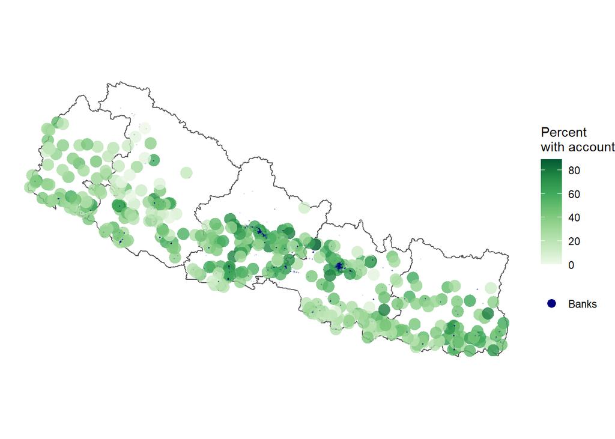

```r
banks.sf<-banks.sf %>%
    filter(rowSums(st_within(banks.sf, borders.sf, sparse=FALSE))==1)

ggplot() +
    geom_sf(data=borders.sf, fill="transparent")  +
    geom_sf(data=st_as_sf(dhs_indiv_sum), aes(fill=trad_fin_prop*100), color="transparent", size=.75, alpha=0.8) +
    scale_fill_distiller(name="Percent\nwith account", palette="Greens", na.value="transparent", direction=1) +
    scale_alpha(range = c(0.00, 0.25), guide = FALSE) +
    geom_sf(data=banks.sf, aes(geometry=geometry, color="Banks"), alpha=0.1, size=.15) +
    scale_color_manual(name="", values=c("Banks" = "navyblue"), guide=guide_legend(override.aes=list(size=3, alpha=1, fill="navyblue")))+
    theme_void() +
    theme(panel.grid.major = element_line(colour = "transparent"), panel.grid.minor = element_blank())
```

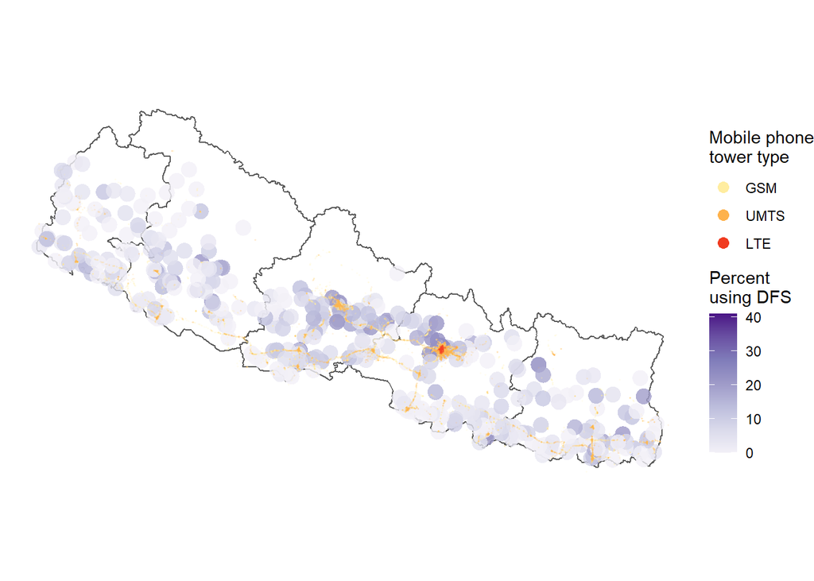

```r
ggplot() +
    geom_sf(data=borders.sf, fill="transparent")  +
    geom_sf(data=st_as_sf(dhs_indiv_sum), aes(fill=mobile_dfs_prop*100), color="transparent", size=.75, alpha=0.8) +
      scale_fill_distiller(name="Percent\nusing DFS", palette="Purples", na.value="transparent", direction=1) +
    scale_alpha(range = c(0.00, 0.25), guide = FALSE) +
    geom_sf(data=cell.sf, aes(geometry=geometry, color=factor(cell.sf$radio, levels=c("GSM", "UMTS","LTE"))), alpha=0.1, size=.15) +
    scale_color_brewer(name="Mobile phone\ntower type", type="seq", palette="YlOrRd", guide=guide_legend(override.aes=list(size=3, alpha=1))) +
    theme_void() +
    theme(panel.grid.major = element_line(colour = "transparent"), panel.grid.minor = element_blank())
```

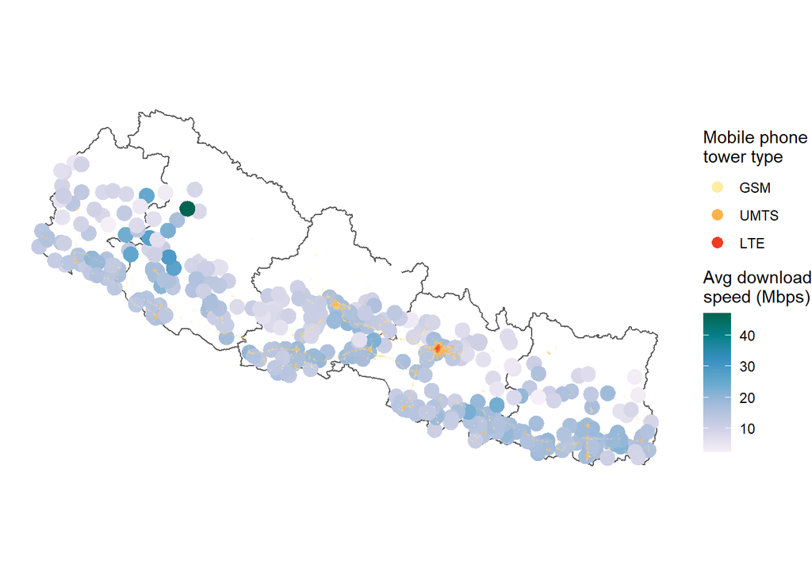

```r
ggplot() +
    geom_sf(data=borders.sf, fill="transparent")  +
    geom_sf(data=st_as_sf(dhs_indiv_sum), aes(fill=download), color="transparent", size=.75, alpha=1) +
    geom_sf(data=cell.sf, aes(geometry=geometry, color=factor(cell.sf$radio, levels=c("GSM", "UMTS","LTE"))), alpha=0.05, size=.15) +
    scale_fill_distiller(name="Avg download\nspeed (Mbps)", palette="PuBuGn", na.value="transparent", direction=1) +
    scale_alpha(range = c(0.00, 0.25), guide = FALSE) +
    scale_color_brewer(name="Mobile phone\ntower type", type="seq", palette="YlOrRd", guide=guide_legend(override.aes=list(size=3, alpha=1))) +
    theme_void() +
    theme(panel.grid.major = element_line(colour = "transparent"), panel.grid.minor = element_blank())
```

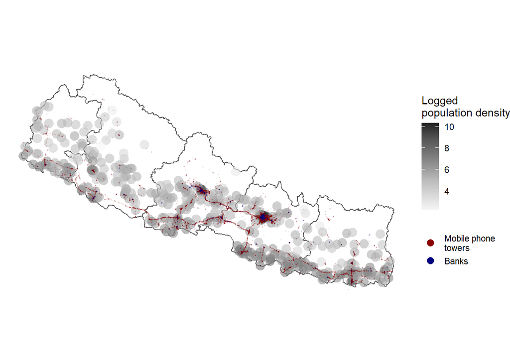

```r
ggplot() +
    geom_sf(data=borders.sf, fill="transparent")  +
    geom_sf(data=st_as_sf(dhs_indiv_sum), aes(fill=log_popden), color="transparent", size=.75, alpha=0.6) +
    scale_fill_distiller(name="Logged\npopulation density", palette="Greys", na.value="transparent", direction=1) +
    scale_alpha(range = c(0.00, 0.25), guide = FALSE) +
    geom_sf(data=cell.sf, aes(geometry=geometry, color="Mobile phone\ntowers"), alpha=0.1, size=.15) +
    geom_sf(data=banks.sf, aes(geometry=geometry, color="Banks"), alpha=0.1, size=.15) +
    scale_color_manual(name="", values=c("Mobile phone\ntowers" = "darkred", "Banks"="navyblue"), guide=guide_legend(override.aes=list(size=3, alpha=1, fill=c("navyblue", "darkred"))))+
    theme_void() +
    theme(panel.grid.major = element_line(colour = "transparent"), panel.grid.minor = element_blank())
```